# **Trends of Mental Health in Tech**

## Introduction

Mental health has been a growing concern over the past few years however it has recently become an issue more present in the public eye. This tutorial is will demonstrate what changes are present in the mental health of individuals over the past two years.

### We will be covering the following topics in this tutorial:

- Installing the Libraries
- Loading and Plotting the Data
- Exploratory Data Analysis
- Conclusion & Insight

### Hypothesis

We will be looking at this data and determining if there is a relation between the mental health of an individual and their gender or the population size of their job or age.

## Getting Started

First, download the 2014 dataset from https://www.kaggle.com/osmi/mental-health-in-tech-survey and the continued 2016 dataset from https://www.kaggle.com/osmi/mental-health-in-tech-2016. This dataset is in the form of a csv(comma-seperated values file) and contains a set of survey questions. We will look at the 2014 answers and the 2016 answers, find trends and then see how we can compare the two datasets. To read the dataset, we have to load our CSV file into a form that we can manipulate using python. To do this, we will use the pandas library. Pandas uses a datatype called a data frame, which puts the data into a table. FTo get a better understanding of pandas and dataframes, you can visit the following pages:

- **Documentation**: http://pandas.pydata.org
- **Pandas Cheat Sheet**: https://www.dataquest.io/blog/images/cheat-sheets/pandas-cheat-sheet.pdf

### Looking at our data

Now we have a pandas data frame called dataframe_2016. Here we can see some of the basic features of our data

```python
#import the following libraries
import pandas as pd
import numpy as np
import matplotlib.pyplot as plt
import matplotlib
import re
%matplotlib inline

#Read csv allows us to read from a csv file and convert it to a dataframe
dataframe_2016 = pd.read_csv('mental-heath-in-tech-2016.csv', index_col=0, parse_dates=True)

#Print out the first 3 values
dataframe_2016.head(3)
```

| Are you self-employed? | How many employees does your company or organization have? | Is your employer primarily a tech company/organization? | Is your primary role within your company related to tech/IT? | Does your employer provide mental health benefits as part of healthcare coverage? | Do you know the options for mental health care available under your employer-provided coverage? | Has your employer ever formally discussed mental health (for example, as part of a wellness campaign or other official communication)? | Does your employer offer resources to learn more about mental health concerns and options for seeking help? | Is your anonymity protected if you choose to take advantage of mental health or substance abuse treatment resources provided by your employer? | If a mental health issue prompted you to request a medical leave from work, asking for that leave would be: | Do you think that discussing a mental health disorder with your employer would have negative consequences? | ... | If you have a mental health issue, do you feel that it interferes with your work when being treated effectively? | If you have a mental health issue, do you feel that it interferes with your work when NOT being treated effectively? | What is your age? | What is your gender? | What country do you live in? | What US state or territory do you live in? | What country do you work in? | What US state or territory do you work in? | Which of the following best describes your work position? | Do you work remotely? |
| --- | --- | --- | --- | --- | --- | --- | --- | --- | --- | --- | --- | --- | --- | --- | --- | --- | --- | --- | --- | --- | --- |
| 0 | 26-100 | 1.0 | NaN | Not eligible for coverage / N/A | NaN | No | No | I don't know | Very easy | No | ... | Not applicable to me | Not applicable to me | 39 | Male | United Kingdom | NaN | United Kingdom | NaN | Back-end Developer | Sometimes |
| 0 | 6-25 | 1.0 | NaN | No | Yes | Yes | Yes | Yes | Somewhat easy | No | ... | Rarely | Sometimes | 29 | male | United States of America | Illinois | United States of America | Illinois | Back-end Developer\|Front-end Developer | Never |
| 0 | 6-25 | 1.0 | NaN | No | NaN | No | No | I don't know | Neither easy nor difficult | Maybe | ... | Not applicable to me | Not applicable to me | 38 | Male | United Kingdom | NaN | United Kingdom | NaN | Back-end Developer | Always |

3 rows × 62 columns

### Tidying our data

#### Too much data!

We can see there are 62 questions and we only want to pick the ones we can use. So we're going to start of by making a new dataframe by selecting only certain column indicies. Make sure to use the .copy() when selecting indicies to ensure a deep copy of the dataframe is created! In addition, the primary key provided by the cvs reader does not have unique values at each row, so we need to create a new index.

#### Inconsistent data

The gender column and company size was an open ended question, so we need to create consistent data. We can do these all by iterating over the dataframe and editing the values.

```python
#Create a deep copy of the dataframe
df_2016 = dataframe_2016[['How many employees does your company or organization have?',
                          'What is your gender?',
                          'Have you been diagnosed with a mental health condition by a medical professional?',
                          'What is your age?',
                           'Which of the following best describes your work position?']].copy()

#Rename the columns
new_columns = ['Company Size','Gender',
                'Do you currently have a mental health disorder?', 'Age',
              'Job title']

df_2016.columns = new_columns

#We can see that our self employed column is actually
#our primary key, we need to change that
df_2016['Self Employed'] = df_2016.index

lst = []
for x in range(0,1433):
    lst.append(x)

df_2016.index = lst


#all the possibilities for male/female
Male = {'Male','male', 'm', 'MALE','M','Male.','Sex is male','cis male','man','Male (cis)','Man','Cis male','cis man','M|',
       'Malr','Dude','Cis Male','cisdude','mail', 'Cis Man', 'Mail', 'Make','Male (CIS)','maile',
       'I\'m a man why didn\'t you make this a drop down question. You should of asked sex? And I would of answered yes please. Seriously how much text can this take?'}
Female = {'Female',' Female', 'female', 'I identify as female.','f','F','Woman','Female assigned at birth'
         ,'Cis female','woman','Cisgender Female','female/woman','Female (props for making this a freeform field, though)',
         'fem','fm','Cis-woman','Female (cis)','Cis Female'}

#Iterate over the dataframe and make the data readable
for index,col in df_2016.iterrows():
    if isinstance(col[0], str):
        company = col[0].rstrip()
        regex = r"(\d+)-(\d+)"
        regex1 = r"(\d+)"
        new_val = 0
        if re.search(regex, company):
            match = re.search(regex, company)
            new_val = int(match.group(2))
        elif company.isdigit():
            new_val = int(company)

        elif company == "More than 1000":
            new_val = 1001
        else:
            new_val = 0
        df_2016.loc[index,'Company Size'] = new_val
    if isinstance(col[1], str):
        sex = col[1].rstrip()
        if sex in Male:
            df_2016.loc[index,'Gender'] = 'M'
        elif sex in Female:
            df_2016.loc[index,'Gender'] = 'F'
        else:
            df_2016.loc[index,'Gender'] = 'other'
    employed = col[5]
    if employed == 1:
        df_2016.loc[index,'Company Size'] = 1


df_2016.head(10)
```

|  | Company Size | Gender | Do you currently have a mental health disorder? | Age | Job title | Self Employed |
| --- | --- | --- | --- | --- | --- | --- |
| 0 | 100 | M | Yes | 39 | Back-end Developer | 0 |
| 1 | 25 | M | Yes | 29 | Back-end Developer\|Front-end Developer | 0 |
| 2 | 25 | M | No | 38 | Back-end Developer | 0 |
| 3 | 1 | M | Yes | 43 | Supervisor/Team Lead | 1 |
| 4 | 25 | F | Yes | 43 | Executive Leadership\|Supervisor/Team Lead\|Dev ... | 0 |
| 5 | 1001 | M | No | 42 | DevOps/SysAdmin\|Support\|Back-end Developer\|Fro... | 0 |
| 6 | 100 | M | No | 30 | Back-end Developer | 0 |
| 7 | 1001 | F | Yes | 37 | Dev Evangelist/Advocate\|Back-end Developer | 0 |
| 8 | 100 | F | Yes | 44 | Support\|Back-end Developer\|One-person shop | 0 |
| 9 | 1 | M | Yes | 30 | One-person shop\|Front-end Developer\|Back-end D... | 1 |

```python
#We can use groupby to get a count of how many males, females and other is in the survey
df_2016.groupby('Gender').size()
```

```
Gender
F         338
M        1057
other      35
dtype: int64
```

### Analyzing our data

Let’s start by creating a bar graph to see if there are noticable trends between having a mental health disorder and the company size, age, gender. The groupby funtion allows us to sort the values in groups by whichever indecies we provide. Here, we see how the company size correlates to the number of people that said yes or no to having a mental health disorder.

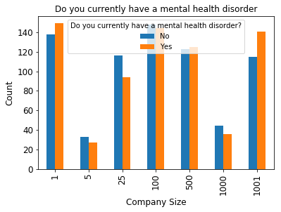

```python
df=df_2016.groupby(['Company Size','Do you currently have a mental health disorder?']).size()
df=df.unstack()
ax = df.plot(kind='bar',title ="Do you currently have a mental health disorder?", legend=True, fontsize=12)
ax.set_xlabel("Company Size", fontsize=12)
ax.set_ylabel("Count", fontsize=12)
ax
```

The above displays a persons size of the company and if they have a mental health disorder. There are no visible trends.

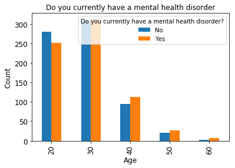

```python
#The original data had a variety of ages, we can use bins to
#round up a persons age to one number then find trends
ranges = [20,30,40,50,60]
df_2016['Rounded Age'] = pd.cut(df_2016['Age'], bins=[20,30,40,50,60,70],labels=ranges)

df=df_2016.groupby(['Rounded Age','Do you currently have a mental health disorder?']).size()
df=df.unstack()
ax = df.plot(kind='bar',title ="Do you currently have a mental health disorder", legend=True, fontsize=12)
ax.set_xlabel("Age", fontsize=12)
ax.set_ylabel("Count", fontsize=12)
ax
```

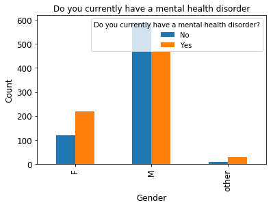

```python
df=df_2016.groupby(['Gender','Do you currently have a mental health disorder?']).size()
df=df.unstack()
ax = df.plot(kind='bar',title ="Do you currently have a mental health disorder", legend=True, fontsize=12)
ax.set_xlabel("Gender", fontsize=12)
ax.set_ylabel("Count", fontsize=12)
ax
```

```python
df_2016.groupby(['Gender','Do you currently have a mental health disorder?']).size()
```

```
Gender  Do you currently have a mental health disorder?
F       No                                                 120
        Yes                                                218
M       No                                                 590
        Yes                                                467
other   No                                                   7
        Yes                                                 28
dtype: int64
```

Here we can see that more women and other have reported that they have been diagnosed with a mental health disorder. We are not saying that more women than men have reported that they have mental health disorders. But, of the 1057 men that answered the survey, 56% said they did not have a mental health disorder, and 44% said they did have one. 64% of women have said they have a mental health disorder.

We should see how each gender in each age has a mental health disorder.

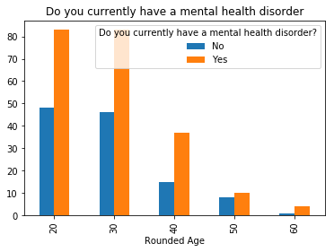

```python
#We create a new dataframe with only the females answers
#then we test how women of different ages responded to having a mental health disorder
f_2016 = df_2016.loc[df_2016['Gender'] == 'F']
df = f_2016.groupby(['Rounded Age','Do you currently have a mental health disorder?']).size()
df = df.unstack()
ax = df.plot(kind='bar', title ="Do you currently have a mental health disorder", legend = True)
ax
```

We can see above that there are more women, no matter what age, that are diagnosed with mental health disorders.

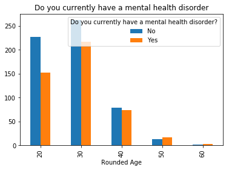

```python
#We can repeat the same process with males
m_2016 = df_2016.loc[df_2016['Gender'] == 'M']
df = m_2016.groupby(['Rounded Age','Do you currently have a mental health disorder?']).size()
df = df.unstack()
ax = df.plot(kind='bar', title ="Do you currently have a mental health disorder", legend = True)
ax
```

Men don't have any correlation with age and the answer to having a mental health disorder.

## What does this mean?

```python
#Read 2014 csv file
dataframe_2014 = pd.read_csv('mental-health-in-tech-2014.csv', index_col=0, parse_dates=True)

df1_2014 = dataframe_2014

lst = []
for x in range(0,1259):
    lst.append(x)

df1_2014.index = lst

#Data Tidying again
Male = {'Male','male', 'm', 'MALE','M','Male.','Sex is male','cis male','man','Male (cis)','Man','Cis male','cis man','M|',
       'Malr','Dude','Cis Male','cisdude','mail', 'Cis Man', 'Mail', 'Make','Male (CIS)','maile', 'msle','Mal',
       'I\'m a man why didn\'t you make this a drop down question. You should of asked sex? And I would of answered yes please. Seriously how much text can this take?'}
Female = {'Female',' Female', 'female', 'I identify as female.','f','F','Woman','Female assigned at birth'
         ,'Cis female','woman','Cisgender Female','female/woman','Female (props for making this a freeform field, though)',
         'fem','fm','Cis-woman','Female (cis)','Cis Female','Femake','femail','cis-female/femme'}


for index,col in df1_2014.iterrows():
    if isinstance(col[8], str):
        company = col[8].rstrip()
        regex = r"(\d+)-(\d+)"
        regex1 = r"(\d+)"
        new_val = 0
        if re.search(regex, company):
            match = re.search(regex, company)
            new_val = int(match.group(2))
        elif company.isdigit():
            new_val = int(company)
        elif company == "More than 1000":
            new_val = 1001
        else:
            new_val = 0
        df1_2014.loc[index,'no_employees'] = new_val
    if isinstance(col[1], str):
        sex = col[1].rstrip()
        if sex in Male:
            df1_2014.loc[index,'Gender'] = 'M'
        elif sex in Female:
            df1_2014.loc[index,'Gender'] = 'F'
        else:
            df1_2014.loc[index,'Gender'] = 'other'

df_2014 = dataframe_2014[['Age', 'Gender','treatment', 'no_employees']].copy()


df_2014.columns = ['Age', 'Gender','Do you currently have a mental health disorder?','Company Size']

df_2014.head(5)
```

|  | Age | Gender | Do you currently have a mental health disorder? | Company Size |
| --- | --- | --- | --- | --- |
| 0 | 37 | F | Yes | 25 |
| 1 | 44 | M | No | 1001 |
| 2 | 32 | M | No | 25 |
| 3 | 31 | M | Yes | 100 |
| 4 | 31 | M | No | 500 |

```python
df_2014.groupby('Gender').size()
```

```
Gender
F        247
M        990
other     22
dtype: int64
```

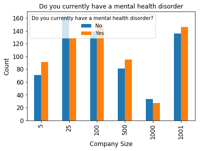

```python
#See the correlation with company size and saying yes
df=df_2014.groupby(['Company Size','Do you currently have a mental health disorder?']).size()
df=df.unstack()
ax = df.plot(kind='bar',title ="Do you currently have a mental health disorder", legend=True, fontsize=12)
ax.set_xlabel("Company Size", fontsize=12)
ax.set_ylabel("Count", fontsize=12)
ax
```

Similar to the 2016 survey, the 2014 doesn't demonstrate any clear trend between those who said yes and the size of the company they worked for.

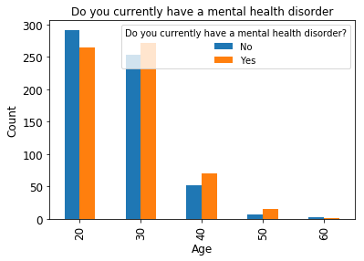

```python
#Once again, compare age to having a mental health disorder
ranges = [20,30,40,50,60]
df_2014['Rounded Age'] = pd.cut(df_2014['Age'], bins=[20,30,40,50,60,70],labels=ranges)

df=df_2014.groupby(['Rounded Age','Do you currently have a mental health disorder?']).size()
df=df.unstack()
ax = df.plot(kind='bar',title ="Do you currently have a mental health disorder", legend=True, fontsize=12)
ax.set_xlabel("Age", fontsize=12)
ax.set_ylabel("Count", fontsize=12)
ax
```

The above displays the correlation between the age and if a person has a mental health disorder. We can see that between the ages of 30 - 50, the population said they were being treated for a mental health disorder.

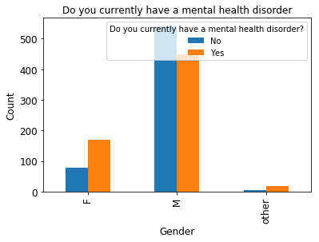

```python
df=df_2014.groupby(['Gender','Do you currently have a mental health disorder?']).size()
df=df.unstack()
ax = df.plot(kind='bar',title ="Do you currently have a mental health disorder", legend=True, fontsize=12)
ax.set_xlabel("Gender", fontsize=12)
ax.set_ylabel("Count", fontsize=12)
ax
```

```python
df_2014.groupby(['Gender','Do you currently have a mental health disorder?']).size()
```

```
Gender  Do you currently have a mental health disorder?
F       No                                                  77
        Yes                                                170
M       No                                                 541
        Yes                                                449
other   No                                                   4
        Yes                                                 18
dtype: int64
```

Again we can see the same trend. Of the 247 women that took this survey, 69% of the women said they have a mental health disorder. Of the 990 men that took this survey, 45% answered yes to having and being treated for a mental health disorder and 55% said did not have one. Let's again analyze then gender alongside the age.

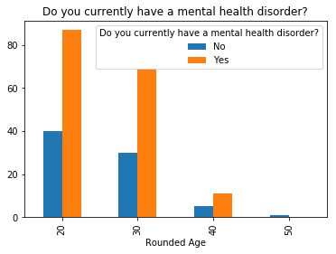

```python
f_2014 = df_2014.loc[dataframe_2014['Gender'] == 'F']
df = f_2014.groupby(['Rounded Age','Do you currently have a mental health disorder?']).size()
df = df.unstack()
ax = df.plot(kind='bar', title ="Do you currently have a mental health disorder?", legend = True)
ax
```

We can again see the same trend in the old data that all women of ages are affected except the age of 50.

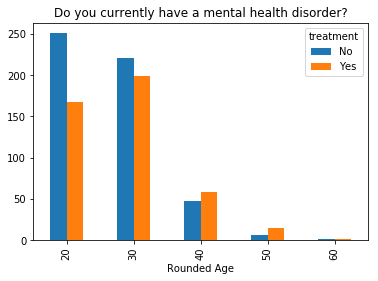

```python
m_2014 = dataframe_2014.loc[dataframe_2014['Gender'] == 'M']
df = m_2014.groupby(['Rounded Age','treatment']).size()
df = df.unstack()
ax = df.plot(kind='bar', title ="Do you currently have a mental health disorder?", legend = True)
ax
```

We can see above that more men over the age of 40 to 60 have said they have mental health disorders.

## Exploratory Data Analysis

In order to make any conclusions, we need to put together the 2014 and 2016 data and continue. We can't compare the women to men, so lets compare then 2014 men to 2016 men and the 2014 women to the 2016 women.

We can combine the two tables on the same values using pandas concat, we have values which we are no longer testing. (Job Title or Self Employed). We can id each data set before hand.

```python
#Add an id to recognize differences
df_2016['Id'] = 2016
df_2014['Id'] = 2014

#Combine 2016 and 2014 dataframes
df_1416 = pd.concat([df_2014, df_2016])

df_1416.head(5)
```

|  | Age | Company Size | Do you currently have a mental health disorder? | Gender | Id | Rounded Age |
| --- | --- | --- | --- | --- | --- | --- |
| 0 | 37 | 25 | Yes | F | 2014 | 30 |
| 1 | 44 | 1001 | No | M | 2014 | 40 |
| 2 | 32 | 25 | No | M | 2014 | 30 |
| 3 | 31 | 100 | Yes | M | 2014 | 30 |
| 4 | 31 | 500 | No | M | 2014 | 30 |

Lets compare each gender to the prior year.

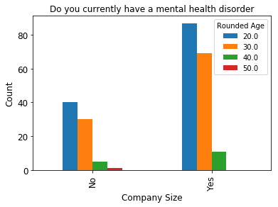

```python
#Create a data frame with only womens answers from 2014 to 2016
f_1416 = df_1416.loc[df_1416['Gender'] == 'F']
df=f_1416.groupby(['Do you currently have a mental health disorder?', 'Rounded Age']).size()
df=df.unstack()
ax = df.plot(kind='bar',title ="Do you currently have a mental health disorder", legend=True, fontsize=12)
ax.set_xlabel("Company Size", fontsize=12)
ax.set_ylabel("Count", fontsize=12)
ax
```

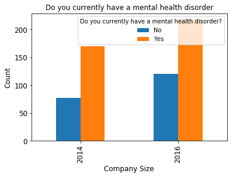

```python
#Same plot as before but now seperating by year
f_1416 = df_1416.loc[df_1416['Gender'] == 'F']
df=f_1416.groupby(['Id','Do you currently have a mental health disorder?']).size()
df=df.unstack()
ax = df.plot(kind='bar',title ="Do you currently have a mental health disorder", legend=True, fontsize=12)
ax.set_xlabel("Company Size", fontsize=12)
ax.set_ylabel("Count", fontsize=12)
ax
```

```python
f_1416.groupby(['Id','Do you currently have a mental health disorder?']).size()
```

```
Id    Do you currently have a mental health disorder?
2014  No                                                  77
      Yes                                                170
2016  No                                                 120
      Yes                                                218
dtype: int64
```

We can see that easily see that 64% women said they had mental health disorder in 2016 and 69% of women said they had a mental health disorder in 2014. This demonstrates that within the women population in tech there is a high population of women who deal with a mental health disorder.

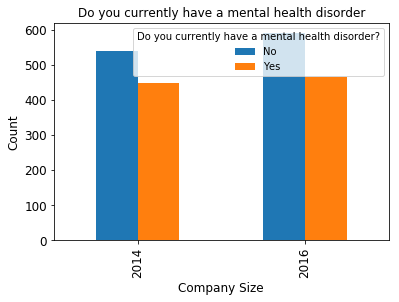

```python
m_1416 = df_1416.loc[df_1416['Gender'] == 'M']
df=m_1416.groupby(['Id','Do you currently have a mental health disorder?']).size()
df=df.unstack()
ax = df.plot(kind='bar',title ="Do you currently have a mental health disorder", legend=True, fontsize=12)
ax.set_xlabel("Company Size", fontsize=12)
ax.set_ylabel("Count", fontsize=12)
ax
```

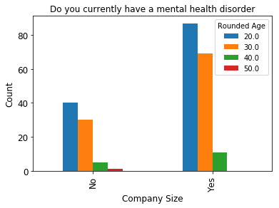

```python
m_1416 = df_1416.loc[df_1416['Gender'] == 'F']
df=m_1416.groupby(['Do you currently have a mental health disorder?', 'Rounded Age']).size()
df=df.unstack()
ax = df.plot(kind='bar',title ="Do you currently have a mental health disorder", legend=True, fontsize=12)
ax.set_xlabel("Company Size", fontsize=12)
ax.set_ylabel("Count", fontsize=12)
ax
```

## Summary

After exploring this dataset, we found that within the tech industry, there is a higher percentage within the women population that have mental health disorder, it is a 6 to 10 ration. For men, it is still 5 to 10. This data set demonstrates that the overall there is a high percentage of individuals that struggle with mental health disorders.